# STA304

2016-03-03

## ratio, regression, difference estimation

## overview

In most actual samples, more than one measurement is available on each unit sampled.

Let's consider the case of two measurements, generically called \(y\) and \(x\).

The population is now \(\{(y_1, x_1),\ldots,(y_N, x_N)\}\) and the sample is \(\{(y_1, x_1),\ldots,(y_n, x_n)\}\) (with the usual abuse of notation.)

Sometimes the population parameter of interest is still the total or mean of the \(y\). Let's call these numbers \(\tau_y\) and \(\mu_y\). We'll also make use of \(\tau_x\) and \(\mu_x\).

If the \(y_i\) and the \(x_i\) in the population are *correlated*, it is possible to get improved estimates of \(\tau_y\) and \(\mu_y\).

Also, sometimes *the actual quantity of interest* is the population ratio itself \(R = \tau_y/\tau_x = \mu_y/\mu_x\).

## a note, and some examples

Note: stratified sampling was a way to use additional information about the units *to design the sampling itself in a different way that can be better*. This part of the course concerns using additional information *in the estimation procedures*.

Examples:

- Consumer Price Index (CPI): a "basket" of consumer goods has its prices measured each month. The \(y\) variable is this month's price and the \(x\) variable is the previous month's price. The ratio of the total basket price is the proportion of increase/decrease in prices.
- "The average amount of screen time per child in households." Unit: household. \(y\): total screen time. \(x\): number of children.
- (Section 6.2): Total amount of sugar in a truckload of oranges. \(y\) is sugar per orange and \(x\) is the weight of an orange.

## estimating the population ratio

I'll use the salary data (a sample from a population of \(N\) = 750) from question 6.10 in the textbook as an example to motivate the concepts.

| Teacher | Past | Present |
| --- | --- | --- |
| 1 | 30400 | 31500 |
| 2 | 31700 | 32600 |
| 3 | 32792 | 33920 |
| 4 | 34956 | 36400 |
| 5 | 31355 | 32020 |
| 6 | 30108 | 31308 |
| 7 | 32891 | 34100 |
| 8 | 30216 | 31320 |
| 9 | 30416 | 31420 |
| 10 | 30397 | 31600 |
| 11 | 33152 | 34560 |
| 12 | 31436 | 32750 |
| 13 | 34192 | 35800 |
| 14 | 32006 | 33300 |
| 15 | 32311 | 33920 |

## estimating the population ratio

\(x\) is the *Past* salary and \(y\) is the *Present*. The goal is to estimate the rate of salary increase for the population. This is the ratio:\[R = \frac{\tau_y}{\tau_x} = \frac{\mu_y}{\mu_x}\]

The obvious way to estimate \(R\) is to use the ratio of the sample totals or sample means:\[\hat R = \frac{\hat\tau_y}{\hat\tau_x} = \frac{\sum_{i=1}^n y_i}{\sum_{i=1}^n x_i} = \frac{{\overline{y}}}{{\overline{x}}} = \frac{\hat\mu_y}{\hat\mu_x}\]which the book mystifyingly calls \(r\) rather than \(\hat R\), so I'll respect that notation.

The basic challenge is that the denominator is random.

## variance of \(r\) - I

It turns out \(r\) is slightly biased for \(R\), but mainly with very small sample sizes. **So we'll go with the assumption that the sample size is not very small**, giving \({E{\left(r\right)}} \approx R\).

The end goal is to get \(V(r) \approx E\left[(r - R)^2\right]\). Start with:

\[r - R = \frac{{\overline{y}}}{{\overline{x}}} - R = \frac{{\overline{y}} - R {\overline{x}}}{{\overline{x}}} \approx \frac{{\overline{y}} - R {\overline{x}}}{\mu_x}\]

Then:

\[V(r) \approx E\left[\left(\frac{{\overline{y}} - R {\overline{x}}}{\mu_x}\right)^2\right] = \frac{1}{\mu_x^2}E\left[\left({\overline{y}} - R {\overline{x}}\right)^2\right]\]

## variance of \(r\) - II

\(\left({\overline{y}} - R {\overline{x}}\right)\) is actually a pretty simple object. Let:

\[r_i = y_i - R x_i\]

Then \(\{r_1,r_2,\ldots,r_n\}\) is a SRS and \({\overline{r}} = \left({\overline{y}} - R {\overline{x}}\right)\) is a sample average with mean 0 and variance that can be copied from the basic SRS theory:\[V({\overline{r}}) = \frac{s^2_r}{n}\left(1-\frac{n}{N}\right)\]with\[s^2_R = \frac{\sum_{i=1}^n \left(r_i - {\overline{r}}\right)^2}{n-1}\]

## variance of \(r\) - III

Putting it all together and we get:

\[V(r) \approx \frac{1}{\mu_x^2}\frac{s^2_R}{n}\left(1-\frac{n}{N}\right)\]

There are a few unknowns in there. \(R\) is never known, and \(\mu_x\) may or may not be known. The conclusion is:

\[\hat V(r) \approx \frac{1}{\mu_x^2}\frac{s^2_r}{n}\left(1-\frac{n}{N}\right) \]

where \(s^2_r\) is \(s^2_R\) with \(r\) used in place of \(R\), and use \({\overline{x}}\) if \(\mu_x\) is unknown.

## salary example

Let's estimate the population salary rate of increase and place the usual bound on the error of estimation \(\left(B = 2\sqrt{\hat V(r)}\right)\).

| x_bar | y_bar | r | s^2_r | B |
| --- | --- | --- | --- | --- |
| 31888.53 | 33101.2 | 1.038028 | 51086.04 | 0.0036234 |

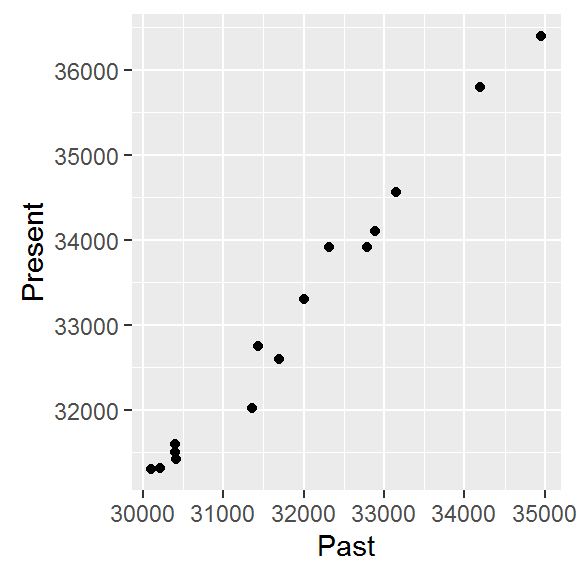

## using \(x\) and ratio technique for estimation of \(\tau_y\)

Ratio estimation might make estimating \(\tau_y\) *better*, or it might even be the only feasible way to do it at all, if \(N\) isn't known and is too difficult to determine, but \(\tau_x\) *is* known.

An example of the latter case the total amount of sugar \(\tau_y\) in a truck of oranges example. (Section 6.2 and Example 6.2). Here \(\tau_x\) is the total weight of the oranges.

In general the usual estimator of \(\tau_y\) is \(N{\overline{y}}\), but always requires \(N\). Another option is:\[\hat\tau_y = r\tau_x\]If the \(y_i\) and \(x_i\) are correlated then this is a better estimator, and if \(N\) is unknown this can be the only feasible estimator.

## estimated variance of \(\hat\tau_y\)

Option 1:\[\hat V(\hat\tau_y) = N^2\left(1-\frac{n}{N}\right)\frac{s^2_r}{n}\]

Option 2 (\(N\) unknown)::\[\hat V(\hat\tau_y) = (\tau_x^2)\frac{1}{\mu_x^2}\frac{s^2_r}{n}\left(1-\frac{n}{N}\right)\]with \({\overline{x}}\) for \(\mu_x\) if required.

## sugar in oranges example

(Raw data not available). A sample of \(n=10\) oranges was taken and the sugar content \(y_i\) and weight \(x_i\) measured. The total weight \(\tau_x\) of all oranges was 1800 pounds.

The estimate of the total sugar in pounds is:

\[\hat\tau_y = r\tau_x = \frac{\sum y_i}{\sum x_i} = \frac{0.246}{4.35}(1800) = 101.79\]

The bound \(B = 2\sqrt{\hat V(\hat\tau_y)}\) requires also to know that \(s^2 = (0.0024)^2\). Plugging all into the formula gives a bound of 6.3